# Context

## Part A - Q3 D - Design new architecture/update existing architecture in attempt to improve the performance of the model.

```python
model1 = keras.Sequential([
    layers.Dense(2560, activation='relu', input_shape=(X_vtrain_scaled.shape[1],)),
    layers.BatchNormalization(),
    layers.Dropout(0.4),

    layers.Dense(1280, activation='relu'),
    layers.BatchNormalization(),
    layers.Dropout(0.4),

    layers.Dense(640, activation='relu'),
    layers.BatchNormalization(),
    layers.Dropout(0.4),

    layers.Dense(320, activation='relu'),
    layers.BatchNormalization(),
    layers.Dropout(0.4),

    layers.Dense(len(set(y_vtrain_encoded)), activation='softmax')
])

# Compile and Train
model1.compile(optimizer=keras.optimizers.Adam(learning_rate=0.0003),
              loss='sparse_categorical_crossentropy', metrics=['accuracy'])
```

```python
history1 = model1.fit(X_vtrain_scaled, y_vtrain_encoded, epochs=150, batch_size=64,
                    validation_data=(X_test_scaled, y_test_encoded))
```

```
15/15 ━━━━━━━━━━━━━━━━━━━━ 6s 121ms/step - accuracy: 0.2773 - loss: 2.5392 - val_accuracy: 0.5441 - val_loss: 1.6406
15/15 ━━━━━━━━━━━━━━━━━━━━ 3s 135ms/step - accuracy: 0.4061 - loss: 1.9861 - val_accuracy: 0.4706 - val_loss: 1.5412
15/15 ━━━━━━━━━━━━━━━━━━━━ 2s 97ms/step - accuracy: 0.4296 - loss: 1.9999 - val_accuracy: 0.4461 - val_loss: 1.4762
15/15 ━━━━━━━━━━━━━━━━━━━━ 2s 129ms/step - accuracy: 0.5033 - loss: 1.6518 - val_accuracy: 0.5368 - val_loss: 1.3780
15/15 ━━━━━━━━━━━━━━━━━━━━ 3s 167ms/step - accuracy: 0.5257 - loss: 1.6354 - val_accuracy: 0.5515 - val_loss: 1.3261
15/15 ━━━━━━━━━━━━━━━━━━━━ 2s 115ms/step - accuracy: 0.4877 - loss: 1.6164 - val_accuracy: 0.4730 - val_loss: 1.2991
15/15 ━━━━━━━━━━━━━━━━━━━━ 2s 101ms/step - accuracy: 0.5393 - loss: 1.5229 - val_accuracy: 0.5368 - val_loss: 1.2469
15/15 ━━━━━━━━━━━━━━━━━━━━ 2s 101ms/step - accuracy: 0.5034 - loss: 1.4968 - val_accuracy: 0.4877 - val_loss: 1.2430
15/15 ━━━━━━━━━━━━━━━━━━━━ 2s 101ms/step - accuracy: 0.5341 - loss: 1.4666 - val_accuracy: 0.5270 - val_loss: 1.2106
15/15 ━━━━━━━━━━━━━━━━━━━━ 1s 99ms/step - accuracy: 0.5565 - loss: 1.4079 - val_accuracy: 0.5270 - val_loss: 1.1753
15/15 ━━━━━━━━━━━━━━━━━━━━ 3s 120ms/step - accuracy: 0.5529 - loss: 1.4206 - val_accuracy: 0.5564 - val_loss: 1.1455
15/15 ━━━━━━━━━━━━━━━━━━━━ 3s 147ms/step - accuracy: 0.5932 - loss: 1.2850 - val_accuracy: 0.5637 - val_loss: 1.1184
15/15 ━━━━━━━━━━━━━━━━━━━━ 1s 96ms/step - accuracy: 0.5836 - loss: 1.3071 - val_accuracy: 0.5686 - val_loss: 1.1028
15/15 ━━━━━━━━━━━━━━━━━━━━ 1s 93ms/step - accuracy: 0.5842 - loss: 1.2363 - val_accuracy: 0.5662 - val_loss: 1.0917
15/15 ━━━━━━━━━━━━━━━━━━━━ 1s 97ms/step - accuracy: 0.5905 - loss: 1.2042 - val_accuracy: 0.5735 - val_loss: 1.0812
15/15 ━━━━━━━━━━━━━━━━━━━━ 3s 98ms/step - accuracy: 0.5952 - loss: 1.1821 - val_accuracy: 0.5637 - val_loss: 1.0690
15/15 ━━━━━━━━━━━━━━━━━━━━ 1s 93ms/step - accuracy: 0.6044 - loss: 1.1852 - val_accuracy: 0.5784 - val_loss: 1.0755
15/15 ━━━━━━━━━━━━━━━━━━━━ 1s 95ms/step - accuracy: 0.6017 - loss: 1.1809 - val_accuracy: 0.5809 - val_loss: 1.0794
15/15 ━━━━━━━━━━━━━━━━━━━━ 2s 150ms/step - accuracy: 0.6330 - loss: 1.1303 - val_accuracy: 0.5515 - val_loss: 1.0771
15/15 ━━━━━━━━━━━━━━━━━━━━ 2s 142ms/step - accuracy: 0.6403 - loss: 0.9837 - val_accuracy: 0.5735 - val_loss: 1.0581
15/15 ━━━━━━━━━━━━━━━━━━━━ 2s 103ms/step - accuracy: 0.6082 - loss: 1.0946 - val_accuracy: 0.5858 - val_loss: 1.0647
15/15 ━━━━━━━━━━━━━━━━━━━━ 2s 97ms/step - accuracy: 0.6353 - loss: 1.0425 - val_accuracy: 0.5784 - val_loss: 1.0770
15/15 ━━━━━━━━━━━━━━━━━━━━ 1s 98ms/step - accuracy: 0.6558 - loss: 0.9967 - val_accuracy: 0.5882 - val_loss: 1.0616
15/15 ━━━━━━━━━━━━━━━━━━━━ 1s 94ms/step - accuracy: 0.6407 - loss: 1.0173 - val_accuracy: 0.5686 - val_loss: 1.0596
15/15 ━━━━━━━━━━━━━━━━━━━━ 1s 99ms/step - accuracy: 0.6515 - loss: 0.9805 - val_accuracy: 0.5858 - val_loss: 1.0729
15/15 ━━━━━━━━━━━━━━━━━━━━ 4s 164ms/step - accuracy: 0.6642 - loss: 0.9433 - val_accuracy: 0.5735 - val_loss: 1.0926
15/15 ━━━━━━━━━━━━━━━━━━━━ 2s 135ms/step - accuracy: 0.6727 - loss: 0.9584 - val_accuracy: 0.5907 - val_loss: 1.0908
15/15 ━━━━━━━━━━━━━━━━━━━━ 1s 98ms/step - accuracy: 0.6696 - loss: 0.9534 - val_accuracy: 0.5907 - val_loss: 1.1139
15/15 ━━━━━━━━━━━━━━━━━━━━ 3s 99ms/step - accuracy: 0.6927 - loss: 0.8841 - val_accuracy: 0.5907 - val_loss: 1.1188
15/15 ━━━━━━━━━━━━━━━━━━━━ 2s 95ms/step - accuracy: 0.6908 - loss: 0.8808 - val_accuracy: 0.5907 - val_loss: 1.1126
15/15 ━━━━━━━━━━━━━━━━━━━━ 3s 102ms/step - accuracy: 0.6491 - loss: 0.9359 - val_accuracy: 0.6005 - val_loss: 1.1540
15/15 ━━━━━━━━━━━━━━━━━━━━ 2s 134ms/step - accuracy: 0.6870 - loss: 0.8219 - val_accuracy: 0.5858 - val_loss: 1.1693
15/15 ━━━━━━━━━━━━━━━━━━━━ 2s 161ms/step - accuracy: 0.6797 - loss: 0.8620 - val_accuracy: 0.5956 - val_loss: 1.1332
15/15 ━━━━━━━━━━━━━━━━━━━━ 2s 100ms/step - accuracy: 0.6798 - loss: 0.8595 - val_accuracy: 0.6005 - val_loss: 1.1401
15/15 ━━━━━━━━━━━━━━━━━━━━ 2s 98ms/step - accuracy: 0.6904 - loss: 0.8176 - val_accuracy: 0.5956 - val_loss: 1.1642
15/15 ━━━━━━━━━━━━━━━━━━━━ 3s 96ms/step - accuracy: 0.7260 - loss: 0.7786 - val_accuracy: 0.5931 - val_loss: 1.1673
15/15 ━━━━━━━━━━━━━━━━━━━━ 3s 96ms/step - accuracy: 0.7045 - loss: 0.8063 - val_accuracy: 0.6005 - val_loss: 1.2198
15/15 ━━━━━━━━━━━━━━━━━━━━ 3s 149ms/step - accuracy: 0.7299 - loss: 0.7397 - val_accuracy: 0.5907 - val_loss: 1.2877
15/15 ━━━━━━━━━━━━━━━━━━━━ 2s 139ms/step - accuracy: 0.7128 - loss: 0.7473 - val_accuracy: 0.5858 - val_loss: 1.2605
15/15 ━━━━━━━━━━━━━━━━━━━━ 1s 95ms/step - accuracy: 0.7340 - loss: 0.6988 - val_accuracy: 0.5760 - val_loss: 1.2972
```

[output cut: 95 more lines]

```
15/15 ━━━━━━━━━━━━━━━━━━━━ 1s 93ms/step - accuracy: 0.9367 - loss: 0.1860 - val_accuracy: 0.5637 - val_loss: 2.4499
15/15 ━━━━━━━━━━━━━━━━━━━━ 3s 106ms/step - accuracy: 0.9340 - loss: 0.1886 - val_accuracy: 0.5490 - val_loss: 2.4520
15/15 ━━━━━━━━━━━━━━━━━━━━ 1s 96ms/step - accuracy: 0.9312 - loss: 0.1805 - val_accuracy: 0.5588 - val_loss: 2.5042
15/15 ━━━━━━━━━━━━━━━━━━━━ 3s 93ms/step - accuracy: 0.9187 - loss: 0.2017 - val_accuracy: 0.5539 - val_loss: 2.5834
15/15 ━━━━━━━━━━━━━━━━━━━━ 3s 143ms/step - accuracy: 0.9258 - loss: 0.1892 - val_accuracy: 0.5760 - val_loss: 2.6192
15/15 ━━━━━━━━━━━━━━━━━━━━ 2s 111ms/step - accuracy: 0.9267 - loss: 0.1826 - val_accuracy: 0.5588 - val_loss: 2.5086
15/15 ━━━━━━━━━━━━━━━━━━━━ 1s 97ms/step - accuracy: 0.9351 - loss: 0.1695 - val_accuracy: 0.5760 - val_loss: 2.6048
15/15 ━━━━━━━━━━━━━━━━━━━━ 3s 99ms/step - accuracy: 0.9241 - loss: 0.2077 - val_accuracy: 0.5613 - val_loss: 2.5844
15/15 ━━━━━━━━━━━━━━━━━━━━ 2s 94ms/step - accuracy: 0.9443 - loss: 0.1653 - val_accuracy: 0.5441 - val_loss: 2.5277
15/15 ━━━━━━━━━━━━━━━━━━━━ 3s 113ms/step - accuracy: 0.9466 - loss: 0.1632 - val_accuracy: 0.5490 - val_loss: 2.5801
15/15 ━━━━━━━━━━━━━━━━━━━━ 3s 152ms/step - accuracy: 0.9407 - loss: 0.1701 - val_accuracy: 0.5515 - val_loss: 2.5022
15/15 ━━━━━━━━━━━━━━━━━━━━ 2s 95ms/step - accuracy: 0.9417 - loss: 0.1548 - val_accuracy: 0.5760 - val_loss: 2.5635
15/15 ━━━━━━━━━━━━━━━━━━━━ 1s 94ms/step - accuracy: 0.9380 - loss: 0.1771 - val_accuracy: 0.5441 - val_loss: 2.5752
15/15 ━━━━━━━━━━━━━━━━━━━━ 1s 94ms/step - accuracy: 0.9533 - loss: 0.1415 - val_accuracy: 0.5588 - val_loss: 2.5519
15/15 ━━━━━━━━━━━━━━━━━━━━ 3s 95ms/step - accuracy: 0.9382 - loss: 0.1728 - val_accuracy: 0.5490 - val_loss: 2.6576
```

## Part A - Q3 E - Plot visuals as in Q3.C and share insights about difference observed in both the models.

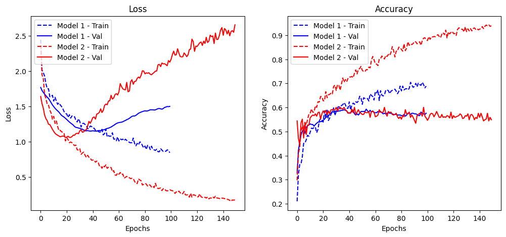

```python
# Create a figure
plt.figure(figsize=(12, 5))

# Plot Loss
plt.subplot(1, 2, 1)
plt.plot(history.history['loss'], 'b--', label='Model 1 - Train')
plt.plot(history.history['val_loss'], 'b', label='Model 1 - Val')
plt.plot(history1.history['loss'], 'r--', label='Model 2 - Train')
plt.plot(history1.history['val_loss'], 'r', label='Model 2 - Val')
plt.title("Loss")
plt.xlabel("Epochs")
plt.ylabel("Loss")
plt.legend()

# Plot Accuracy
plt.subplot(1, 2, 2)
plt.plot(history.history['accuracy'], 'b--', label='Model 1 - Train')
plt.plot(history.history['val_accuracy'], 'b', label='Model 1 - Val')
plt.plot(history1.history['accuracy'], 'r--', label='Model 2 - Train')
plt.plot(history1.history['val_accuracy'], 'r', label='Model 2 - Val')
plt.title("Accuracy")
plt.xlabel("Epochs")
plt.ylabel("Accuracy")
plt.legend()

plt.show()
```

### **Key Takeaways**

- Model 2 **learns faster** but **overfits** more.
- Model 1 **is more stable** but **learns slower**.
- **To improve generalization**, techniques like **early stopping** or **regularization** can be used.

# PART-B

## Part B - Q1 A - Read the .h5 file and assign to a variable.

```python
import random
from tensorflow.keras import backend
random.seed(1)
np.random.seed(1)
tf.random.set_seed(1)
warnings.filterwarnings("ignore")
```

```python
from google.colab import drive
drive.mount('/content/grive')
```

```python
!pip install h5py
```

## Part B - Q1 A - Read the .h5 file and assign to a variable.

```python
#df = pd.DataFrame(np.array(h5py.File('/content/grive/MyDrive/Autonomous_Vehicles_SVHN_single_grey1.h5', 'r')['df']))

hf = h5py.File("/content/grive/MyDrive/AIML/Projects/Autonomous_Vehicles_SVHN_single_grey1.h5")
#df = pd.DataFrame(np.array(hf))
```

## Part B - Q1 B - Print all the keys from the .h5 file.

```python
# Printing all keys from the .h5 file

hf.keys()
```

```
<KeysViewHDF5 ['X_test', 'X_train', 'X_val', 'y_test', 'y_train', 'y_val']>
```

## Part B - Q1 C - Split the data into X_train, X_test, Y_train, Y_test

```python
# load the already split train, validation and test data into different representative variables

X_train = hf['X_train'][:]
y_train = hf['y_train'][:]

X_val = hf['X_val'][:]
y_val = hf['y_val'][:]

X_test = hf['X_test'][:]
y_test = hf['y_test'][:]
```

## Part B - Q2 A - Print shape of all the 4 data split into x, y, train, test to verify if x & y is in sync.

```python
# Printing the shapes of the split datasets

print("X train set shape :", X_train.shape)
print("y train set shape :", y_train.shape, '\n')

print("X validation set shape :", X_val.shape)
print("y validation set shape :", y_val.shape, '\n')

print("X test set shape :", X_test.shape)
print("y test set shape :", y_test.shape)
```

```
X train set shape : (42000, 32, 32)
y train set shape : (42000,)

X validation set shape : (60000, 32, 32)
y validation set shape : (60000,)

X test set shape : (18000, 32, 32)
y test set shape : (18000,)
```

### **Observation on Dataset Shapes**

- The dataset is well-balanced, with a large number of training (42,000), validation (60,000), and test (18,000) samples.
- Each sample is a 32×32 image, suggesting a structured image classification task.

## Part B - Q2 B - Visualise first 10 images in train data and print its corresponding labels.

```
label for each of the below image in the order: 2
label for each of the below image in the order: 6
label for each of the below image in the order: 7
label for each of the below image in the order: 4
label for each of the below image in the order: 4
label for each of the below image in the order: 0
label for each of the below image in the order: 3
label for each of the below image in the order: 0
label for each of the below image in the order: 7
label for each of the below image in the order: 3
```

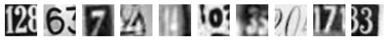

```python
#Visualizing the 10 images in the dataset and printing its corresponding labels

plt.figure(figsize=(10, 1))
for i in range(10):
    plt.subplot(1, 10, i+1)
    plt.imshow(X_train[i], cmap="gray")
    plt.axis('off')
    print('label for each of the below image in the order: %s' % ((y_train[i])))
plt.show()
```

## Part B - Q2 C -Reshape all the images with appropriate shape update the data in same variable.

```python
# Flattening out the X data/Reshaping X data to make it Neural Network ready

X_train = X_train.reshape(42000, 32*32)
X_val= X_val.reshape(X_val.shape[0], 32*32)
X_test = X_test.reshape(X_test.shape[0], 32*32)

print(f'Shape of X_train is {X_train.shape}')
print(f'Shape of X_val is {X_val.shape}')
print(f'Shape of X_test is {X_test.shape}')
```

```
Shape of X_train is (42000, 1024)
Shape of X_val is (60000, 1024)
Shape of X_test is (18000, 1024)
```

## Part B - Q2 D - Normalise the images i.e. Normalise the pixel values.

```python
# Normalising the image pixels

X_test = pd.DataFrame(X_test)
X_train = pd.DataFrame(X_train)
X_val = pd.DataFrame(X_val)

X_train_scaled = X_train.apply(zscore)
X_test_scaled = X_test.apply(zscore)
X_val_scaled = X_val.apply(zscore)
```

```python
print('After Normalization \n')

print(f'Min value is : \n\n{X_train_scaled.min()} \n')
print(f'Max value is : \n\n{X_train_scaled.max()}')
```

```
After Normalization

Min value is :

0      -2.158478
1      -2.164138
2      -2.146480
3      -2.157187
4      -2.170026
          ...
1019   -2.119158
1020   -2.192968
1021   -2.195509
1022   -2.180609
1023   -2.174923
Length: 1024, dtype: float32

Max value is :

0       2.746893
1       2.746240
2       2.738500
3       2.730738
4       2.718849
          ...
1019    2.749752
1020    2.769468
1021    2.783767
1022    2.790589
1023    2.782456
Length: 1024, dtype: float32
```

## Part B - Q2 E - Transform Labels into format acceptable by Neural Network

```python
# Transforming the dataset labels into format accepted by the Neural Network

y_train_new = tf.keras.utils.to_categorical(y_train,num_classes=10)
y_val_new= tf.keras.utils.to_categorical(y_val,num_classes=10)
y_test_new= tf.keras.utils.to_categorical(y_test, num_classes=10)

print(f'first row of the target variable in training set {y_train_new[0]}')
```

```
first row of the target variable in training set [0. 0. 1. 0. 0. 0. 0. 0. 0. 0.]
```

### **Target Variable (First Row in Training Set)**

The target variable is **one-hot encoded**, where each row represents a class with a **1** in the corresponding position and **0s** elsewhere.

## Part B - Q2 F - Print total Number of classes in the Dataset.

```python
print(type(y_train))
print(type(y_test))

y_train = pd.DataFrame(y_train)
y_test = pd.DataFrame(y_test)
y_val = pd.DataFrame(y_val)

y = pd.concat([y_train, y_val, y_test], ignore_index=True)

print(y.shape)
```

[output not shown]

```python
print (f'List of classes in the Dataset : \n\n{y.value_counts()}\n\n')
print (f'Total number of classes in the Dataset : \n\n{y.nunique()}')
```

```
List of classes in the Dataset :

0
0    12000
1    12000
2    12000
3    12000
4    12000
5    12000
6    12000
7    12000
8    12000
9    12000
Name: count, dtype: int64


Total number of classes in the Dataset :

0    10
dtype: int64
```

### **Dataset Information**

The dataset consists of **10 classes**, each containing **12,000 samples**, ensuring a **balanced distribution** across all categories.

## Part B - Q3 A - Design a Neural Network to train a classifier.

```python
# Designing Neural Network  Architechture and training the neural network with the training dataset

def neural_network_model():

  backend.clear_session()
  #Fixing the seed for random number generators so that we can ensure we receive the same output everytime
  random.seed(42)
  tf.random.set_seed(42)

  model= Sequential()
  model.add(BatchNormalization(input_shape=((1024,))))
  model.add(Dense(256,activation='relu'))
  model.add(Dense(64,activation='relu'))
  model.add(Dense(32,activation='relu'))
  model.add(Dense(10,activation='softmax'))

  # compile the model

  sgd = optimizers.Adam(learning_rate=1e-3)  # Corrected line
  model.compile(loss=losses.categorical_crossentropy,optimizer=sgd,metrics=['accuracy'])
  return model

# Build the model
model = neural_network_model()

# Fit the model
history1 = model.fit(X_train_scaled,y_train_new, validation_data=(X_val_scaled,y_val_new),epochs=30,batch_size=200,verbose=2)
scores= model.evaluate(X_test_scaled,y_test_new,verbose=0)
print(f"Error:%.2f%% %(100-scores[1]*100) \n")
print('Validation Accuracy :', scores[1])
```

```
210/210 - 9s - 41ms/step - accuracy: 0.4799 - loss: 1.5376 - val_accuracy: 0.6749 - val_loss: 1.0465
210/210 - 4s - 19ms/step - accuracy: 0.7053 - loss: 0.9517 - val_accuracy: 0.7409 - val_loss: 0.8412
210/210 - 6s - 30ms/step - accuracy: 0.7530 - loss: 0.8006 - val_accuracy: 0.7688 - val_loss: 0.7530
210/210 - 5s - 22ms/step - accuracy: 0.7822 - loss: 0.7096 - val_accuracy: 0.7958 - val_loss: 0.6722
210/210 - 4s - 19ms/step - accuracy: 0.8000 - loss: 0.6515 - val_accuracy: 0.8082 - val_loss: 0.6307
210/210 - 7s - 31ms/step - accuracy: 0.8133 - loss: 0.6051 - val_accuracy: 0.8140 - val_loss: 0.6143
210/210 - 4s - 20ms/step - accuracy: 0.8261 - loss: 0.5658 - val_accuracy: 0.8266 - val_loss: 0.5682
210/210 - 5s - 25ms/step - accuracy: 0.8383 - loss: 0.5239 - val_accuracy: 0.8335 - val_loss: 0.5487
210/210 - 10s - 48ms/step - accuracy: 0.8471 - loss: 0.4949 - val_accuracy: 0.8367 - val_loss: 0.5399
210/210 - 5s - 24ms/step - accuracy: 0.8534 - loss: 0.4723 - val_accuracy: 0.8414 - val_loss: 0.5253
210/210 - 5s - 22ms/step - accuracy: 0.8574 - loss: 0.4610 - val_accuracy: 0.8506 - val_loss: 0.5001
210/210 - 5s - 24ms/step - accuracy: 0.8673 - loss: 0.4272 - val_accuracy: 0.8446 - val_loss: 0.5160
210/210 - 10s - 49ms/step - accuracy: 0.8723 - loss: 0.4120 - val_accuracy: 0.8521 - val_loss: 0.4987
210/210 - 11s - 54ms/step - accuracy: 0.8768 - loss: 0.3977 - val_accuracy: 0.8566 - val_loss: 0.4816
210/210 - 5s - 25ms/step - accuracy: 0.8816 - loss: 0.3780 - val_accuracy: 0.8591 - val_loss: 0.4767
210/210 - 6s - 28ms/step - accuracy: 0.8871 - loss: 0.3633 - val_accuracy: 0.8660 - val_loss: 0.4584
210/210 - 5s - 25ms/step - accuracy: 0.8905 - loss: 0.3538 - val_accuracy: 0.8640 - val_loss: 0.4626
210/210 - 12s - 56ms/step - accuracy: 0.8926 - loss: 0.3431 - val_accuracy: 0.8632 - val_loss: 0.4681
210/210 - 9s - 42ms/step - accuracy: 0.8939 - loss: 0.3420 - val_accuracy: 0.8642 - val_loss: 0.4651
210/210 - 10s - 49ms/step - accuracy: 0.8960 - loss: 0.3321 - val_accuracy: 0.8707 - val_loss: 0.4492
210/210 - 9s - 43ms/step - accuracy: 0.9033 - loss: 0.3099 - val_accuracy: 0.8725 - val_loss: 0.4425
210/210 - 5s - 24ms/step - accuracy: 0.9019 - loss: 0.3114 - val_accuracy: 0.8655 - val_loss: 0.4712
210/210 - 6s - 30ms/step - accuracy: 0.9039 - loss: 0.3054 - val_accuracy: 0.8641 - val_loss: 0.4752
210/210 - 5s - 25ms/step - accuracy: 0.9093 - loss: 0.2923 - val_accuracy: 0.8706 - val_loss: 0.4630
210/210 - 9s - 41ms/step - accuracy: 0.9114 - loss: 0.2847 - val_accuracy: 0.8788 - val_loss: 0.4382
210/210 - 10s - 47ms/step - accuracy: 0.9146 - loss: 0.2750 - val_accuracy: 0.8691 - val_loss: 0.4673
210/210 - 8s - 39ms/step - accuracy: 0.9151 - loss: 0.2683 - val_accuracy: 0.8655 - val_loss: 0.4924
210/210 - 8s - 36ms/step - accuracy: 0.9197 - loss: 0.2578 - val_accuracy: 0.8752 - val_loss: 0.4562
210/210 - 10s - 48ms/step - accuracy: 0.9187 - loss: 0.2593 - val_accuracy: 0.8789 - val_loss: 0.4458
210/210 - 7s - 32ms/step - accuracy: 0.9203 - loss: 0.2534 - val_accuracy: 0.8727 - val_loss: 0.4760
Error:%.2f%% %(100-scores[1]*100)

Validation Accuracy : 0.8143333196640015
```

### **Training Summary**

```python
# Probability output for the first sample data displayed

y_test_pred = model.predict(X_test_scaled)
y_test_pred[0]
```

```
563/563 ━━━━━━━━━━━━━━━━━━━━ 1s 2ms/step
```

```
array([0.0512742 , 0.82230896, 0.01929138, 0.00691257, 0.00592386,
       0.02084234, 0.01356163, 0.03456228, 0.01180617, 0.01351652],
      dtype=float32)
```

```python
# As our outputs are probabilities so we will try to extract the output class from these probablities by getting the maximum value

y_test_pred_final = []
for i in y_test_pred:
  y_test_pred_final.append(np.argmax(i))

# Output class of sample data input 3

y_test_pred_final[3]
```

```
np.int64(9)
```

```python
# MODEL PERFORMANCE EVALUATION

# Classification Report for the model

print(classification_report(y_test, y_test_pred_final))
```

```
              precision    recall  f1-score   support

           0       0.87      0.82      0.85      1814
           1       0.84      0.80      0.82      1828
           2       0.86      0.82      0.84      1803
           3       0.77      0.78      0.78      1719
           4       0.74      0.90      0.81      1812
           5       0.76      0.84      0.80      1768
           6       0.79      0.81      0.80      1832
           7       0.88      0.86      0.87      1808
           8       0.81      0.75      0.78      1812
           9       0.83      0.77      0.80      1804

    accuracy                           0.81     18000
   macro avg       0.82      0.81      0.81     18000
weighted avg       0.82      0.81      0.81     18000
```

### **Classification Report Summary**

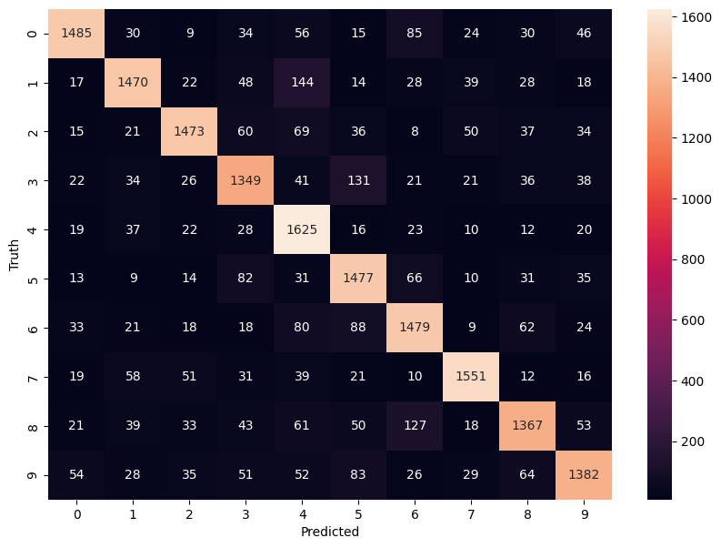

```python
# Confusion Matrix

cm = confusion_matrix(y_test,y_test_pred_final)

plt.figure(figsize=(10,7))
sns.heatmap(cm,annot=True,fmt='d')
plt.xlabel('Predicted')
plt.ylabel('Truth')
plt.show()
```

### **Observations**

- The confusion matrix shows strong diagonal dominance, indicating good classification performance.
- Some misclassifications exist, especially in similar-looking classes, suggesting scope for further fine-tuning.

## Part B - Q3 B - Train the classifier using previously designed Architecture (Use best suitable parameters).

```python
from tensorflow.keras.backend import clear_session

# Fixing random seed for reproducibility
random.seed(42)
tf.random.set_seed(42)

# Define the improved neural network model
def neural_network_model():
    clear_session()  # Clears memory ✅ FIXED

    model = Sequential([
        BatchNormalization(input_shape=(1024,)),  # Input Normalization
        Dense(256, activation='relu'),
        Dropout(0.3),  # Prevent Overfitting
        Dense(128, activation='relu'),
        Dropout(0.2),
        Dense(64, activation='relu'),
        Dense(10, activation='softmax')  # 10 output classes
    ])

    # Adam optimizer with reduced learning rate
    adam_optimizer = optimizers.Adam(learning_rate=5e-4)

    # Compile model
    model.compile(loss=losses.categorical_crossentropy, optimizer=adam_optimizer, metrics=['accuracy'])

    return model

# Build the model
model = neural_network_model()


# Build the model
model = neural_network_model()


from tensorflow.keras.callbacks import EarlyStopping, ModelCheckpoint

early_stopping = EarlyStopping(monitor='val_loss', patience=10, restore_best_weights=True)
model_checkpoint = ModelCheckpoint("best_model.h5", save_best_only=True, monitor="val_accuracy")
```

```python
# Train the model
history2 = model.fit(X_train_scaled, y_train_new,
                    validation_data=(X_val_scaled, y_val_new),
                    epochs=100, batch_size=128, verbose=2,
                    callbacks=[early_stopping, model_checkpoint])

# Evaluate the model
scores = model.evaluate(X_test_scaled, y_test_new, verbose=0)

# Print accuracy results
print(f"Test Accuracy: {scores[1] * 100:.2f}%")
print(f"Validation Accuracy: {scores[1]:.4f}")
```

```
329/329 - 6s - 19ms/step - accuracy: 0.8801 - loss: 0.3672 - val_accuracy: 0.9201 - val_loss: 0.2777
329/329 - 8s - 24ms/step - accuracy: 0.8847 - loss: 0.3590 - val_accuracy: 0.9183 - val_loss: 0.2807
329/329 - 9s - 26ms/step - accuracy: 0.8821 - loss: 0.3624 - val_accuracy: 0.9202 - val_loss: 0.2742
329/329 - 7s - 21ms/step - accuracy: 0.8826 - loss: 0.3600 - val_accuracy: 0.9190 - val_loss: 0.2768
```

[output not shown]

```
329/329 - 10s - 31ms/step - accuracy: 0.8848 - loss: 0.3570 - val_accuracy: 0.9225 - val_loss: 0.2700
329/329 - 9s - 29ms/step - accuracy: 0.8820 - loss: 0.3595 - val_accuracy: 0.9214 - val_loss: 0.2719
329/329 - 10s - 31ms/step - accuracy: 0.8806 - loss: 0.3621 - val_accuracy: 0.9214 - val_loss: 0.2734
329/329 - 9s - 28ms/step - accuracy: 0.8853 - loss: 0.3566 - val_accuracy: 0.9184 - val_loss: 0.2790
```

[output not shown]

```
329/329 - 6s - 19ms/step - accuracy: 0.8861 - loss: 0.3520 - val_accuracy: 0.9237 - val_loss: 0.2664
329/329 - 10s - 31ms/step - accuracy: 0.8841 - loss: 0.3542 - val_accuracy: 0.9221 - val_loss: 0.2709
329/329 - 10s - 31ms/step - accuracy: 0.8811 - loss: 0.3594 - val_accuracy: 0.9216 - val_loss: 0.2717
329/329 - 10s - 31ms/step - accuracy: 0.8848 - loss: 0.3563 - val_accuracy: 0.9234 - val_loss: 0.2681
329/329 - 6s - 18ms/step - accuracy: 0.8834 - loss: 0.3530 - val_accuracy: 0.9209 - val_loss: 0.2726
329/329 - 10s - 29ms/step - accuracy: 0.8840 - loss: 0.3566 - val_accuracy: 0.9236 - val_loss: 0.2675
```

[output not shown]

```
329/329 - 11s - 34ms/step - accuracy: 0.8850 - loss: 0.3538 - val_accuracy: 0.9239 - val_loss: 0.2677
```

[output not shown]

```
329/329 - 6s - 17ms/step - accuracy: 0.8853 - loss: 0.3508 - val_accuracy: 0.9240 - val_loss: 0.2666
329/329 - 11s - 33ms/step - accuracy: 0.8850 - loss: 0.3526 - val_accuracy: 0.9213 - val_loss: 0.2735
```

[output not shown]

```
329/329 - 8s - 23ms/step - accuracy: 0.8871 - loss: 0.3476 - val_accuracy: 0.9243 - val_loss: 0.2634
```

[output not shown]

```
329/329 - 6s - 19ms/step - accuracy: 0.8862 - loss: 0.3518 - val_accuracy: 0.9245 - val_loss: 0.2649
```

[output not shown]

```
329/329 - 10s - 31ms/step - accuracy: 0.8857 - loss: 0.3488 - val_accuracy: 0.9266 - val_loss: 0.2611
329/329 - 11s - 35ms/step - accuracy: 0.8884 - loss: 0.3448 - val_accuracy: 0.9242 - val_loss: 0.2629
329/329 - 6s - 18ms/step - accuracy: 0.8889 - loss: 0.3427 - val_accuracy: 0.9237 - val_loss: 0.2668
329/329 - 10s - 31ms/step - accuracy: 0.8855 - loss: 0.3491 - val_accuracy: 0.9222 - val_loss: 0.2714
329/329 - 10s - 32ms/step - accuracy: 0.8855 - loss: 0.3510 - val_accuracy: 0.9240 - val_loss: 0.2644
329/329 - 12s - 36ms/step - accuracy: 0.8888 - loss: 0.3435 - val_accuracy: 0.9247 - val_loss: 0.2653
329/329 - 9s - 26ms/step - accuracy: 0.8869 - loss: 0.3465 - val_accuracy: 0.9255 - val_loss: 0.2610
329/329 - 7s - 21ms/step - accuracy: 0.8887 - loss: 0.3403 - val_accuracy: 0.9238 - val_loss: 0.2650
329/329 - 5s - 15ms/step - accuracy: 0.8881 - loss: 0.3463 - val_accuracy: 0.9261 - val_loss: 0.2609
```

[output not shown]

```
329/329 - 8s - 23ms/step - accuracy: 0.8887 - loss: 0.3442 - val_accuracy: 0.9269 - val_loss: 0.2589
329/329 - 6s - 19ms/step - accuracy: 0.8898 - loss: 0.3420 - val_accuracy: 0.9226 - val_loss: 0.2696
329/329 - 8s - 24ms/step - accuracy: 0.8877 - loss: 0.3443 - val_accuracy: 0.9254 - val_loss: 0.2609
```

[output not shown]

```
329/329 - 9s - 26ms/step - accuracy: 0.8876 - loss: 0.3421 - val_accuracy: 0.9286 - val_loss: 0.2572
329/329 - 10s - 31ms/step - accuracy: 0.8920 - loss: 0.3341 - val_accuracy: 0.9267 - val_loss: 0.2585
```

[output not shown]

```
329/329 - 10s - 31ms/step - accuracy: 0.8869 - loss: 0.3424 - val_accuracy: 0.9292 - val_loss: 0.2549
329/329 - 6s - 20ms/step - accuracy: 0.8907 - loss: 0.3399 - val_accuracy: 0.9264 - val_loss: 0.2604
329/329 - 5s - 16ms/step - accuracy: 0.8886 - loss: 0.3409 - val_accuracy: 0.9271 - val_loss: 0.2590
329/329 - 13s - 38ms/step - accuracy: 0.8875 - loss: 0.3408 - val_accuracy: 0.9277 - val_loss: 0.2562
329/329 - 6s - 19ms/step - accuracy: 0.8906 - loss: 0.3327 - val_accuracy: 0.9273 - val_loss: 0.2560
329/329 - 8s - 23ms/step - accuracy: 0.8918 - loss: 0.3311 - val_accuracy: 0.9284 - val_loss: 0.2547
329/329 - 9s - 26ms/step - accuracy: 0.8917 - loss: 0.3363 - val_accuracy: 0.9278 - val_loss: 0.2552
329/329 - 7s - 21ms/step - accuracy: 0.8909 - loss: 0.3328 - val_accuracy: 0.9287 - val_loss: 0.2525
329/329 - 5s - 15ms/step - accuracy: 0.8924 - loss: 0.3311 - val_accuracy: 0.9268 - val_loss: 0.2571
329/329 - 7s - 21ms/step - accuracy: 0.8910 - loss: 0.3329 - val_accuracy: 0.9282 - val_loss: 0.2524
329/329 - 5s - 15ms/step - accuracy: 0.8920 - loss: 0.3317 - val_accuracy: 0.9280 - val_loss: 0.2544
329/329 - 9s - 27ms/step - accuracy: 0.8914 - loss: 0.3303 - val_accuracy: 0.9289 - val_loss: 0.2543
329/329 - 6s - 18ms/step - accuracy: 0.8924 - loss: 0.3290 - val_accuracy: 0.9287 - val_loss: 0.2542
329/329 - 10s - 31ms/step - accuracy: 0.8900 - loss: 0.3388 - val_accuracy: 0.9287 - val_loss: 0.2541
329/329 - 6s - 18ms/step - accuracy: 0.8932 - loss: 0.3277 - val_accuracy: 0.9287 - val_loss: 0.2532
329/329 - 10s - 31ms/step - accuracy: 0.8950 - loss: 0.3234 - val_accuracy: 0.9285 - val_loss: 0.2528
329/329 - 10s - 31ms/step - accuracy: 0.8937 - loss: 0.3258 - val_accuracy: 0.9287 - val_loss: 0.2514
```

[output not shown]

```
329/329 - 9s - 28ms/step - accuracy: 0.8915 - loss: 0.3327 - val_accuracy: 0.9299 - val_loss: 0.2498
329/329 - 6s - 19ms/step - accuracy: 0.8914 - loss: 0.3303 - val_accuracy: 0.9293 - val_loss: 0.2540
329/329 - 7s - 22ms/step - accuracy: 0.8932 - loss: 0.3250 - val_accuracy: 0.9298 - val_loss: 0.2482
329/329 - 6s - 18ms/step - accuracy: 0.8938 - loss: 0.3255 - val_accuracy: 0.9273 - val_loss: 0.2559
329/329 - 9s - 28ms/step - accuracy: 0.8924 - loss: 0.3304 - val_accuracy: 0.9276 - val_loss: 0.2547
329/329 - 7s - 21ms/step - accuracy: 0.8960 - loss: 0.3179 - val_accuracy: 0.9290 - val_loss: 0.2498
329/329 - 10s - 31ms/step - accuracy: 0.8940 - loss: 0.3248 - val_accuracy: 0.9298 - val_loss: 0.2495
```

[output not shown]

```
329/329 - 11s - 33ms/step - accuracy: 0.8948 - loss: 0.3223 - val_accuracy: 0.9310 - val_loss: 0.2476
329/329 - 11s - 32ms/step - accuracy: 0.8944 - loss: 0.3223 - val_accuracy: 0.9299 - val_loss: 0.2493
329/329 - 6s - 18ms/step - accuracy: 0.8942 - loss: 0.3241 - val_accuracy: 0.9287 - val_loss: 0.2549
329/329 - 7s - 21ms/step - accuracy: 0.8930 - loss: 0.3255 - val_accuracy: 0.9298 - val_loss: 0.2493
329/329 - 8s - 26ms/step - accuracy: 0.8939 - loss: 0.3226 - val_accuracy: 0.9303 - val_loss: 0.2491
329/329 - 8s - 23ms/step - accuracy: 0.8955 - loss: 0.3195 - val_accuracy: 0.9301 - val_loss: 0.2500
329/329 - 9s - 26ms/step - accuracy: 0.8965 - loss: 0.3190 - val_accuracy: 0.9301 - val_loss: 0.2491
329/329 - 10s - 31ms/step - accuracy: 0.8949 - loss: 0.3179 - val_accuracy: 0.9289 - val_loss: 0.2530
329/329 - 10s - 31ms/step - accuracy: 0.8963 - loss: 0.3188 - val_accuracy: 0.9305 - val_loss: 0.2488
```

[output not shown]

```
329/329 - 9s - 27ms/step - accuracy: 0.8969 - loss: 0.3198 - val_accuracy: 0.9328 - val_loss: 0.2431
329/329 - 6s - 19ms/step - accuracy: 0.8953 - loss: 0.3185 - val_accuracy: 0.9287 - val_loss: 0.2521
329/329 - 9s - 28ms/step - accuracy: 0.8964 - loss: 0.3199 - val_accuracy: 0.9304 - val_loss: 0.2479
329/329 - 6s - 18ms/step - accuracy: 0.8990 - loss: 0.3133 - val_accuracy: 0.9297 - val_loss: 0.2501
329/329 - 9s - 28ms/step - accuracy: 0.8967 - loss: 0.3186 - val_accuracy: 0.9314 - val_loss: 0.2438
329/329 - 7s - 21ms/step - accuracy: 0.8960 - loss: 0.3192 - val_accuracy: 0.9311 - val_loss: 0.2476
329/329 - 6s - 18ms/step - accuracy: 0.8949 - loss: 0.3190 - val_accuracy: 0.9314 - val_loss: 0.2463
329/329 - 11s - 34ms/step - accuracy: 0.8953 - loss: 0.3197 - val_accuracy: 0.9311 - val_loss: 0.2449
329/329 - 12s - 38ms/step - accuracy: 0.8997 - loss: 0.3109 - val_accuracy: 0.9322 - val_loss: 0.2456
329/329 - 6s - 18ms/step - accuracy: 0.8991 - loss: 0.3108 - val_accuracy: 0.9316 - val_loss: 0.2445
329/329 - 7s - 22ms/step - accuracy: 0.8980 - loss: 0.3142 - val_accuracy: 0.9313 - val_loss: 0.2473
Test Accuracy: 87.27%
Validation Accuracy: 0.8727
```